# TP3 - Exercice 1

Tracy ANDRE

April 30, 2023

TP3 : Régression linéaire multiple

EXERCICE 1 : Effet de la publicité sur les ventes d’un produit

Question 1

```r
setwd("C:/Users/andre/OneDrive/Documents/S6/Stats/TP3_Donnees")
pub <- read.table("Advertising.csv",header=T, row.names = 1, sep=",")

attach(pub)

head(pub)
```

|  | TV | Radio | Newspaper | Sales |
| --- | --- | --- | --- | --- |
| 1 | 230.1 | 37.8 | 69.2 | 22.1 |
| 2 | 44.5 | 39.3 | 45.1 | 10.4 |
| 3 | 17.2 | 45.9 | 69.3 | 9.3 |
| 4 | 151.5 | 41.3 | 58.5 | 18.5 |
| 5 | 180.8 | 10.8 | 58.4 | 12.9 |
| 6 | 8.7 | 48.9 | 75.0 | 7.2 |

```r
summary(pub)
```

```
##        TV             Radio          Newspaper          Sales
##  Min.   :  0.70   Min.   : 0.000   Min.   :  0.30   Min.   : 1.60
##  1st Qu.: 74.38   1st Qu.: 9.975   1st Qu.: 12.75   1st Qu.:10.38
##  Median :149.75   Median :22.900   Median : 25.75   Median :12.90
##  Mean   :147.04   Mean   :23.264   Mean   : 30.55   Mean   :14.02
##  3rd Qu.:218.82   3rd Qu.:36.525   3rd Qu.: 45.10   3rd Qu.:17.40
##  Max.   :296.40   Max.   :49.600   Max.   :114.00   Max.   :27.00
```

Question 2

```r
correlation <- cor(pub)
correlation
```

```
##                   TV      Radio  Newspaper     Sales
## TV        1.00000000 0.05480866 0.05664787 0.7822244
## Radio     0.05480866 1.00000000 0.35410375 0.5762226
## Newspaper 0.05664787 0.35410375 1.00000000 0.2282990
## Sales     0.78222442 0.57622257 0.22829903 1.0000000
```

Question 3 : Régression linéaire simple de la variable Sales sur la variable TV

- nuage de points :

```r
plot(y= pub$Sales, x = pub$TV, ylab="Ventes", xlab="TV", pch=19)
reg=lm(pub$Sales~TV,data=pub)
resume=summary(reg)
resume
```

```
##
## Call:
## lm(formula = pub$Sales ~ TV, data = pub)
##
## Residuals:
##     Min      1Q  Median      3Q     Max
## -8.3860 -1.9545 -0.1913  2.0671  7.2124
##
## Coefficients:
##             Estimate Std. Error t value Pr(>|t|)
## (Intercept) 7.032594   0.457843   15.36   <2e-16 ***
## TV          0.047537   0.002691   17.67   <2e-16 ***
## ---
## Signif. codes:  0 '***' 0.001 '**' 0.01 '*' 0.05 '.' 0.1 ' ' 1
##
## Residual standard error: 3.259 on 198 degrees of freedom
## Multiple R-squared:  0.6119, Adjusted R-squared:  0.6099
## F-statistic: 312.1 on 1 and 198 DF,  p-value: < 2.2e-16
```

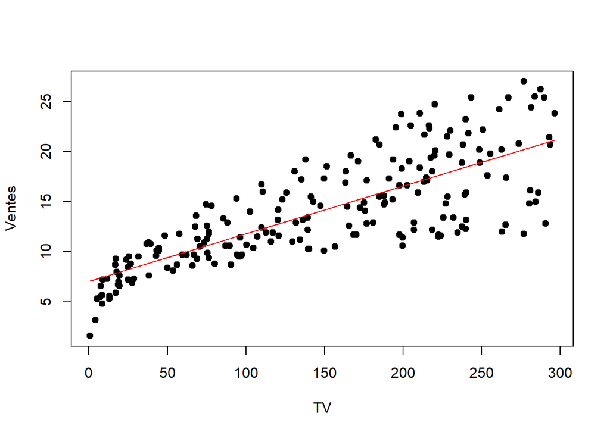

```r
x=c(min(pub$TV),max(pub$TV))
y = reg$coeff[1] + reg$coeff[2]*x
lines(x,y,col="red")
```

- graphe des résidus

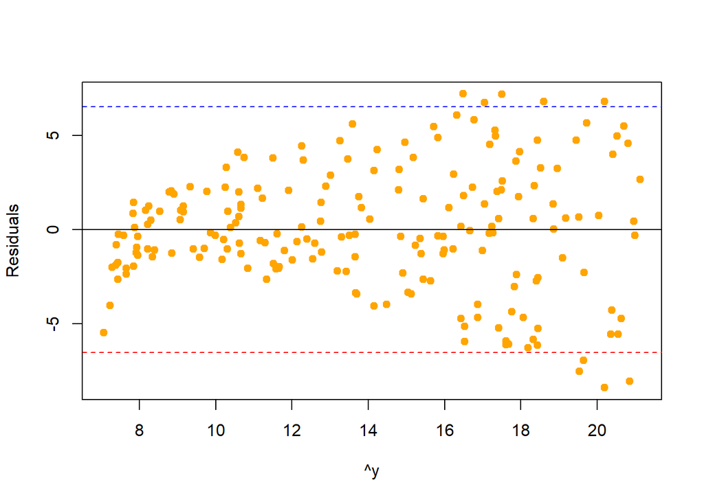

```r
plot(x = reg$fitted.values,y = reg$residuals, xlab="^y",ylab="Residuals", pch=19, col="orange")
abline(h=0)
abline(h=-2*resume$sigma,lty=2, col = "red")
abline(h=2*resume$sigma, col="blue", lty=2)
```

Le modèle est-il bien ajusté aux données ? Le budget alloué à la publicité à la télévision a-t-il une influence sur les ventes du produit ? => Le modèle ne semble pas ajusté aux données car la variance n’est pas constante dans le 1er graphe => Les données ne sont pas réparties aléatoirement donc cela laisse penser que le budget TV a une influence sur les ventes

Question 4

Avec la variable Radio

```r
plot(y= pub$Sales, x = pub$Radio, ylab="Ventes", xlab="Radio", pch=19)
reg1=lm(pub$Sales~Radio,data=pub)
resume=summary(reg1)
resume
```

```
##
## Call:
## lm(formula = pub$Sales ~ Radio, data = pub)
##
## Residuals:
##      Min       1Q   Median       3Q      Max
## -15.7305  -2.1324   0.7707   2.7775   8.1810
##
## Coefficients:
##             Estimate Std. Error t value Pr(>|t|)
## (Intercept)  9.31164    0.56290  16.542   <2e-16 ***
## Radio        0.20250    0.02041   9.921   <2e-16 ***
## ---
## Signif. codes:  0 '***' 0.001 '**' 0.01 '*' 0.05 '.' 0.1 ' ' 1
##
## Residual standard error: 4.275 on 198 degrees of freedom
## Multiple R-squared:  0.332,  Adjusted R-squared:  0.3287
## F-statistic: 98.42 on 1 and 198 DF,  p-value: < 2.2e-16
```

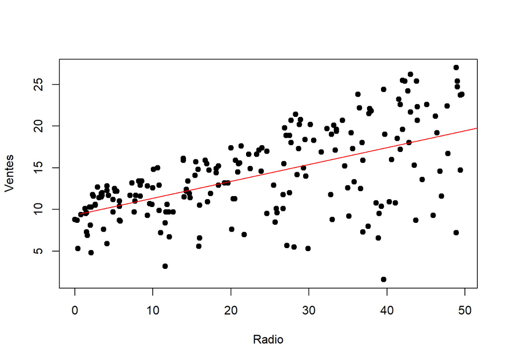

```r
x=c(min(pub$TV),max(pub$TV))
y = reg1$coeff[1] + reg1$coeff[2]*x
lines(x,y,col="red")
```

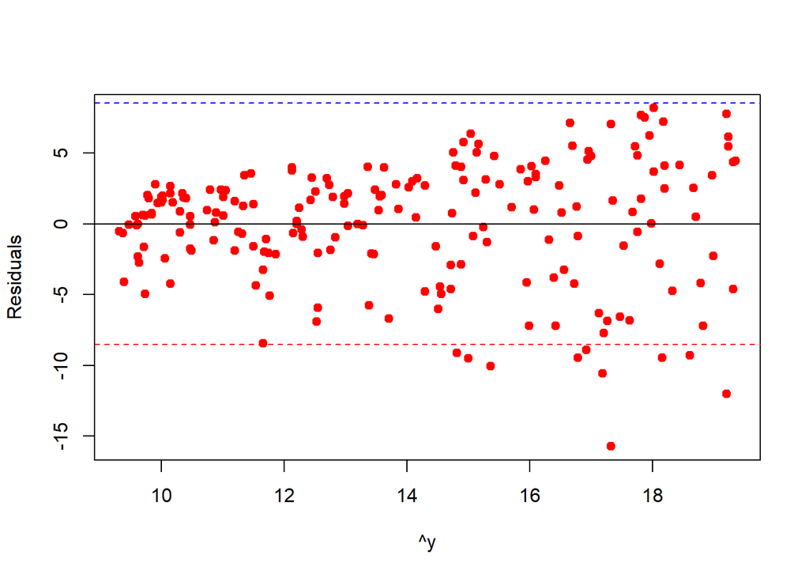

```r
plot(x = reg1$fitted.values,y = reg1$residuals, xlab="^y",ylab="Residuals", pch=19, col="red")
abline(h=0)
abline(h=-2*resume$sigma,lty=2, col = "red")
abline(h=2*resume$sigma, col="blue", lty=2)
```

Avec la variable Newspapers

```r
plot(y= pub$Sales, x = pub$Newspaper, ylab="Ventes", xlab="Journaux", pch=19)
reg2=lm(pub$Sales~Newspaper,data=pub)
resume=summary(reg2)
resume
```

```
##
## Call:
## lm(formula = pub$Sales ~ Newspaper, data = pub)
##
## Residuals:
##      Min       1Q   Median       3Q      Max
## -11.2272  -3.3873  -0.8392   3.5059  12.7751
##
## Coefficients:
##             Estimate Std. Error t value Pr(>|t|)
## (Intercept) 12.35141    0.62142   19.88  < 2e-16 ***
## Newspaper    0.05469    0.01658    3.30  0.00115 **
## ---
## Signif. codes:  0 '***' 0.001 '**' 0.01 '*' 0.05 '.' 0.1 ' ' 1
##
## Residual standard error: 5.092 on 198 degrees of freedom
## Multiple R-squared:  0.05212,    Adjusted R-squared:  0.04733
## F-statistic: 10.89 on 1 and 198 DF,  p-value: 0.001148
```

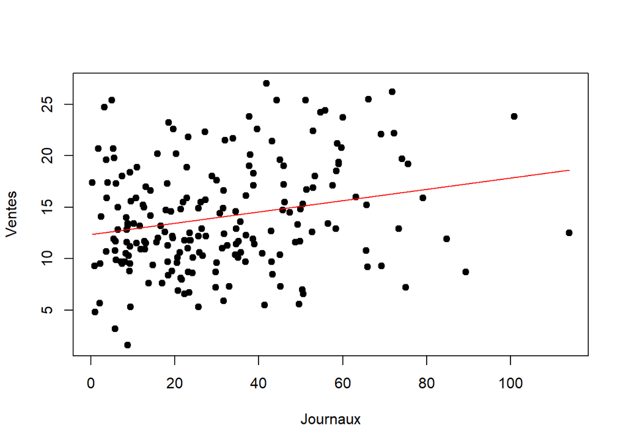

```r
x=c(min(pub$Newspaper),max(pub$Newspaper))
y = reg2$coeff[1] + reg2$coeff[2]*x
lines(x,y,col="red")
```

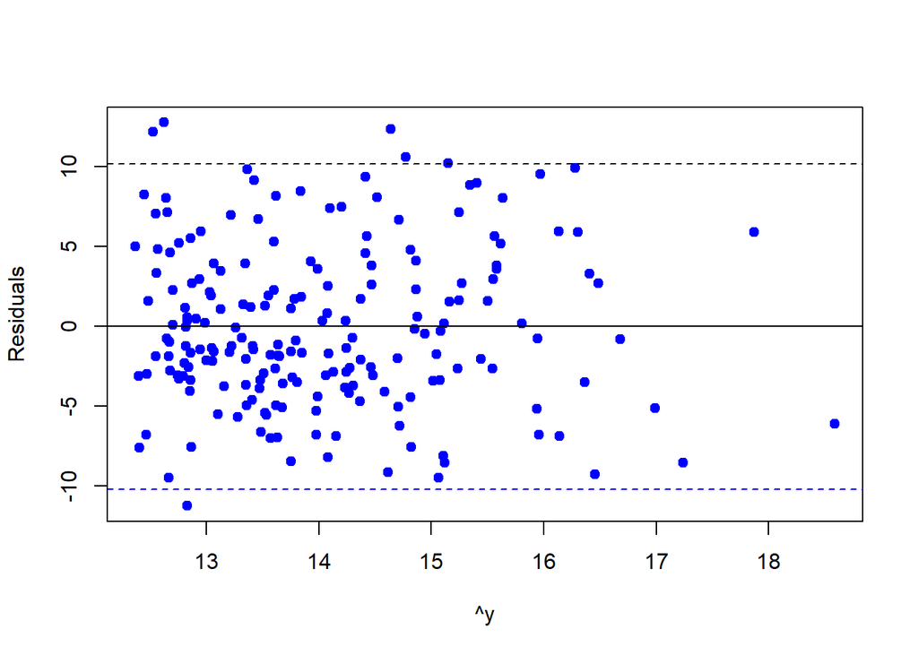

```r
plot(x = reg2$fitted.values,y = reg2$residuals, xlab="^y",ylab="Residuals", pch=19, col="blue")
abline(h=0)
abline(h=-2*resume$sigma,lty=2, col = "blue")
abline(h=2*resume$sigma, lty=2)
```

NB : dans toutes les régressions, il faudrait regarder les R², la p value et regarder la cohérence (comme au TP2) // TODO significativement différent de 0 au risque de 5

R² => à quel point explique la variabilité de y

Question 5 - Régression multiple sur 3 variables

```r
reg=lm(formula = Sales~TV+Radio+Newspaper, data=pub)
reg$coefficients
```

```
##  (Intercept)           TV        Radio    Newspaper
##  2.938889369  0.045764645  0.188530017 -0.001037493
```

On peut lire dans l’ordre : beta0^, beta1^ … etc avec beta0^ la quantité qu’on va vendre si on ne fait ni TV, ni Radio, ni Journaux

```r
summary(reg)
```

```
##
## Call:
## lm(formula = Sales ~ TV + Radio + Newspaper, data = pub)
##
## Residuals:
##     Min      1Q  Median      3Q     Max
## -8.8277 -0.8908  0.2418  1.1893  2.8292
##
## Coefficients:
##              Estimate Std. Error t value Pr(>|t|)
## (Intercept)  2.938889   0.311908   9.422   <2e-16 ***
## TV           0.045765   0.001395  32.809   <2e-16 ***
## Radio        0.188530   0.008611  21.893   <2e-16 ***
## Newspaper   -0.001037   0.005871  -0.177     0.86
## ---
## Signif. codes:  0 '***' 0.001 '**' 0.01 '*' 0.05 '.' 0.1 ' ' 1
##
## Residual standard error: 1.686 on 196 degrees of freedom
## Multiple R-squared:  0.8972, Adjusted R-squared:  0.8956
## F-statistic: 570.3 on 3 and 196 DF,  p-value: < 2.2e-16
```

Attention pour le R² on doit prendre l’ajuster pour observer la variabilité des ventes est expliqué par le modèle (ici 0.8956) sigma chapeau c’est residual sd error : 1.686

Question 6

Peut-on affrmer, avec un risque d’erreur de 5 %, qu’au moins une des variables explicatives a une influence sur la quantité de produits vendus ?

test global => beta1=beta2=beta3=0 => la proba critique est toute petite donc rejeter => donc au moins une qui n’est pas nulle la statistique = F-statistic =>

Question 7 Peut-on affrmer, avec un risque d’erreur de 5 %, que le budget alloué à la publicité à la télévision a une influence sur les ventes du produit ?

Intercept = beta0 sur la 1ère ligne : on test beta1 = 0 => proba critique petite => beta1 pas nul sur la 2ème ligne beta2 = 0 => proba petite => beta2 pas nul sur la 3ème ligne : beta3 =0 => proba gde => beta3 considéré comme nul

NB : on peut regarder les *** à coté du test => donne le degrés de proche de 0

Question 8

```r
reg=lm(formula = Sales~TV+Radio, data=pub)
reg$coefficients
```

```
## (Intercept)          TV       Radio
##  2.92109991  0.04575482  0.18799423
```

```r
summary(reg)
```

```
##
## Call:
## lm(formula = Sales ~ TV + Radio, data = pub)
##
## Residuals:
##     Min      1Q  Median      3Q     Max
## -8.7977 -0.8752  0.2422  1.1708  2.8328
##
## Coefficients:
##             Estimate Std. Error t value Pr(>|t|)
## (Intercept)  2.92110    0.29449   9.919   <2e-16 ***
## TV           0.04575    0.00139  32.909   <2e-16 ***
## Radio        0.18799    0.00804  23.382   <2e-16 ***
## ---
## Signif. codes:  0 '***' 0.001 '**' 0.01 '*' 0.05 '.' 0.1 ' ' 1
##
## Residual standard error: 1.681 on 197 degrees of freedom
## Multiple R-squared:  0.8972, Adjusted R-squared:  0.8962
## F-statistic: 859.6 on 2 and 197 DF,  p-value: < 2.2e-16
```

F-statistic gde => donc une des deux variables qui explique qqch On remarque que le coefficient beta2^ est + gd que l’autre donc il semblerait + jusdicieux de mettre les 10 000€ dans la radio lorsqu’on augmente d’1 unité => 0.18 pour 10 milliers de dollars => 0.18 * 10 = 1.8 milliers nb d’unité

// normalement faut faire les cmd en dessous mais faut installer

```r
# library(rgl)
# library(car)
# scatter3d(Sales~TV+Radio, data=pub)
```

Question 10

Notre client a investi 100 000 dollars dans la TV et 20 000 dans la radio Combien de produit devrait-il vendre ?

```r
model <- lm(Sales ~ TV + Radio + Newspaper, data=pub)

predict(model, newdata = data.frame(TV = 100, Radio = 20, Newspaper = 0), interval = "prediction")
```

```
##        fit      lwr      upr
## 1 11.28595 7.934592 14.63732
```